# Exploring the BRFSS data

## Setup

### Load packages

```r
library(ggplot2)
library(dplyr)
library(gridExtra)
library(vcd)
library(reshape2)
```

### Load data

```r
load("brfss2013.RData")
```

## Part 1: Data

The sample is a good representative of the population . Interviewers used stratified random sampling to conduct both landline telephone and cellular telephone-based surveys. Whereas randomly selected adults in households used the landline means, others who resided in private-residences/college-housing participated by using a cellular telephones. A wide coverage of selected questions was set up during the data collection to adress most essential factors hence well adressing topic of interest and consequently generalizable to US population.

It is not possible to infer causality since the experiment was done over a chosens strata of people; Hence different experiment groups were not randomly selected but were prechosen. It is clear that this study is observational and not experimental. There were levels of conveniences adopted as research was clustered into telephone or cellular with voluntary particpation; In addition, some reseacrch was categorically approached based on certain selection criteria and not random. These factors may raise bias when attempting to estimate the population parameters. However the bias problem was fairly resolved by introducing the weighting technique and by collecting a large volume of data over a wide variety of features.

It is therefore very clear that this random sample is appropriate for estimating the population parameters.

## Part 2: Data Cleaning

```r
df<-select(brfss2013,cvdinfr4,cvdcrhd4,cvdstrk3,asthma3,asthnow,chcscncr,chcocncr,chccopd1,havarth3,addepev2,chckidny,diabete3,veteran3,marital,children,educa,employ1,income2,weight2,height3,numhhol2,numphon2,cpdemo1,cpdemo4,internet,renthom1,sex,pregnant,qlactlm2,useequip,blind,decide,diffwalk,diffdres,diffalon,lmtjoin3,arthdis2,arthsocl,joinpain)

df_new<-df[complete.cases(df$joinpain), ]
total_length<-length(attributes(df_new)$row)
```

```r
sum_nan<-data.frame(t(colSums(is.na(df_new),dims = 1)))
record_drop = list()
for (name in colnames(sum_nan)){
  if (c(sum_nan[name])>0.33*total_length)
    record_drop<-append(record_drop,name)
}
df_new <- subset(df_new, select = !(names(df_new) %in% record_drop))
summary(df_new)
```

```
##  cvdinfr4      cvdcrhd4      cvdstrk3      asthma3       chcscncr
##  Yes : 15069   Yes : 16146   Yes : 10671   Yes : 27302   Yes : 21118
##  No  :131586   No  :129407   No  :136386   No  :119827   No  :126089
##  NA's:  1055   NA's:  2157   NA's:   653   NA's:   581   NA's:   503
##
##
##
##
##  chcocncr      chccopd1      havarth3      addepev2      chckidny
##  Yes : 21377   Yes : 22575   Yes :147708   Yes : 43412   Yes :  8690
##  No  :125909   No  :123929   No  :     1   No  :103566   No  :138277
##  NA's:   424   NA's:  1206   NA's:     1   NA's:   732   NA's:   743
##
##
##
##
##                                        diabete3      veteran3
##  Yes                                       : 30250   Yes : 21440
##  Yes, but female told only during pregnancy:  1039   No  :126151
##  No                                        :112382   NA's:   119
##  No, pre-diabetes or borderline diabetes   :  3816
##  NA's                                      :   223
##
##
##                             marital         children
##  Married                        :71248   Min.   : 0.0000
##  Divorced                       :25928   1st Qu.: 0.0000
##  Widowed                        :31613   Median : 0.0000
##  Separated                      : 3501   Mean   : 0.2493
##  Never married                  :12400   3rd Qu.: 0.0000
##  A member of an unmarried couple: 2439   Max.   :17.0000
##  NA's                           :  581   NA's   :286
##                                                           educa
##  Never attended school or only kindergarten                  :  203
##  Grades 1 through 8 (Elementary)                             : 5052
##  Grades 9 though 11 (Some high school)                       :10598
##  Grade 12 or GED (High school graduate)                      :47384
##  College 1 year to 3 years (Some college or technical school):41934
##  College 4 years or more (College graduate)                  :42204
##  NA's                                                        :  335
```

[output cut: 25 more lines]

```
##  Yes : 13362   Yes : 25566   Yes :55379   Yes : 14164   Yes : 22794
##  No  :133864   No  :121115   No  :91571   No  :133267   No  :124322
##  NA's:   484   NA's:  1029   NA's:  760   NA's:   279   NA's:   594
##
##
##
##
##  lmtjoin3     arthdis2           arthsocl        joinpain
##  Yes :73042   Yes :47010   A lot     :27746   Min.   : 0.000
##  No  :73591   No  :97171   A little  :35535   1st Qu.: 3.000
##  NA's: 1077   NA's: 3529   Not at all:83586   Median : 5.000
##                            NA's      :  843   Mean   : 4.705
##                                               3rd Qu.: 7.000
##                                               Max.   :10.000
##
```

```r
for (name in colnames(df_new)){
  class_<-attributes(df_new[,name])$class
  if (length(class_)){
    t<-table(df_new[,name])
    most_freq <-attributes(sort(t,decreasing = TRUE)[1])$names
    df_new[,name][is.na(df_new[,name])] <- most_freq
  }
  else{
    t<-df_new[,name]
    ave<-mean(t, na.rm = TRUE)
    df_new[,name][is.na(df_new[,name])] <- ave
  }
}
summary(df_new)
```

```
##  cvdinfr4     cvdcrhd4     cvdstrk3     asthma3      chcscncr
##  Yes: 15069   Yes: 16146   Yes: 10671   Yes: 27302   Yes: 21118
##  No :132641   No :131564   No :137039   No :120408   No :126592
##
##
##
##
##
##  chcocncr     chccopd1     havarth3     addepev2     chckidny
##  Yes: 21377   Yes: 22575   Yes:147709   Yes: 43412   Yes:  8690
##  No :126333   No :125135   No :     1   No :104298   No :139020
##
##
##
##
##
##                                        diabete3      veteran3
##  Yes                                       : 30250   Yes: 21440
##  Yes, but female told only during pregnancy:  1039   No :126270
##  No                                        :112605
##  No, pre-diabetes or borderline diabetes   :  3816
##
##
##
##                             marital         children
##  Married                        :71829   Min.   : 0.0000
##  Divorced                       :25928   1st Qu.: 0.0000
##  Widowed                        :31613   Median : 0.0000
##  Separated                      : 3501   Mean   : 0.2493
##  Never married                  :12400   3rd Qu.: 0.0000
##  A member of an unmarried couple: 2439   Max.   :17.0000
##
##                                                           educa
##  Never attended school or only kindergarten                  :  203
##  Grades 1 through 8 (Elementary)                             : 5052
##  Grades 9 though 11 (Some high school)                       :10598
##  Grade 12 or GED (High school graduate)                      :47719
##  College 1 year to 3 years (Some college or technical school):41934
##  College 4 years or more (College graduate)                  :42204
##
```

[output cut: 25 more lines]

```
##  Yes: 13362   Yes: 25566   Yes:55379   Yes: 14164   Yes: 22794
##  No :134348   No :122144   No :92331   No :133546   No :124916
##
##
##
##
##
##  lmtjoin3    arthdis2           arthsocl        joinpain
##  Yes:73042   Yes: 47010   A lot     :27746   Min.   : 0.000
##  No :74668   No :100700   A little  :35535   1st Qu.: 3.000
##                           Not at all:84429   Median : 5.000
##                                              Mean   : 4.705
##                                              3rd Qu.: 7.000
##                                              Max.   :10.000
##
```

## analyse

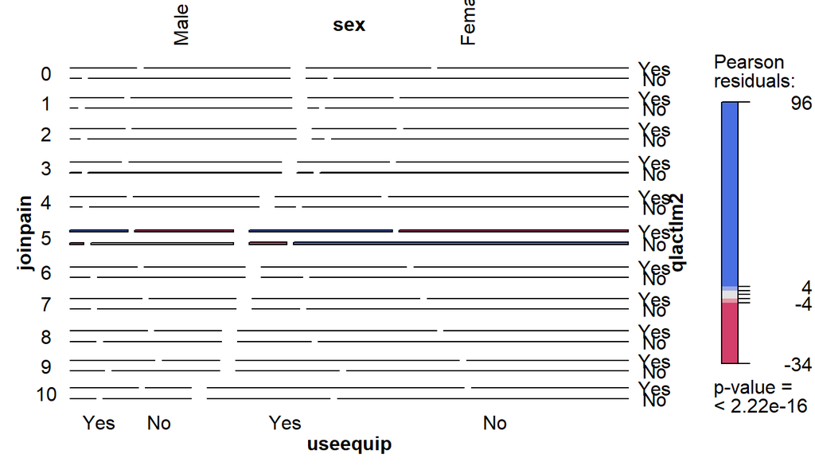

```r
brfss = df_new
count_group<-brfss %>% count(joinpain,sex,qlactlm2,useequip)

dt <- xtabs(n~sex+qlactlm2+useequip+joinpain, data = count_group)
df<-ftable(dt)

mosaic( ~joinpain+sex+qlactlm2+useequip,dt,shade=TRUE,legend=TRUE,color=TRUE,zero_size = 5,labeling= labeling_border(rot_labels = c(90,0,0,0),
                                 just_labels = c("left", "center")))
```

```r
Titanic
```

[output not shown]

**Research quesion 2:**

```r
# Counts of adults with bad and good health report across the states
state_health <- brfss2013 %>%
  group_by(X_state, X_rfhlth) %>%
  filter(!is.na(X_state),!is.na(X_rfhlth)) %>%
  summarise(count = n())
gbh <- state_health %>%
  filter(X_rfhlth == "Good or Better Health") %>%
  group_by(X_state, X_rfhlth) %>%
  arrange(desc(count))
head(gbh)
```

```
## # A tibble: 6 x 3
## # Groups:   X_state, X_rfhlth [6]
##   X_state       X_rfhlth              count
##   <fct>         <fct>                 <int>
## 1 Florida       Good or Better Health 25529
## 2 Kansas        Good or Better Health 19317
## 3 Nebraska      Good or Better Health 14321
## 4 Minnesota     Good or Better Health 12395
## 5 Massachusetts Good or Better Health 12357
## 6 Colorado      Good or Better Health 11694
```

As shown above `Good or Better Health` type is lead by `Florida` and `Kansas` respectively.

```r
fph <- state_health %>%
  filter(X_rfhlth == "Fair or Poor Health") %>%
  group_by(X_state, X_rfhlth) %>%
  arrange(desc(count))
head(fph)
```

```
## # A tibble: 6 x 3
## # Groups:   X_state, X_rfhlth [6]
##   X_state       X_rfhlth            count
##   <fct>         <fct>               <int>
## 1 Florida       Fair or Poor Health  7776
## 2 Kansas        Fair or Poor Health  3911
## 3 Kentucky      Fair or Poor Health  2938
## 4 Nebraska      Fair or Poor Health  2785
## 5 Massachusetts Fair or Poor Health  2685
## 6 Ohio          Fair or Poor Health  2494
```

The health type `Fair or Poor Health` is also dominated by `Florida` and `Kansas` respectively.

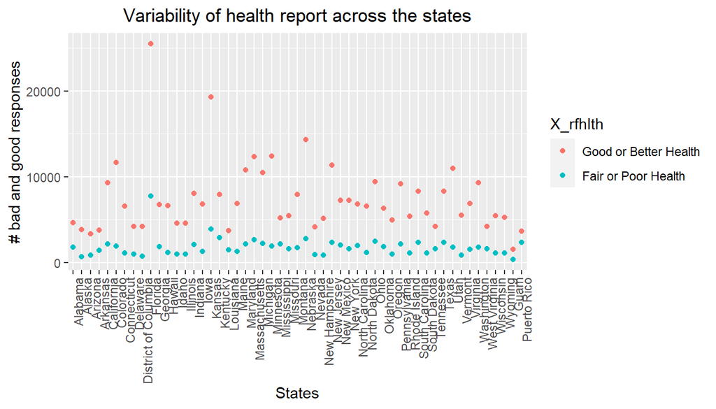

```r
ggplot(data = state_health, aes(x = X_state, y = count, color = X_rfhlth)) +
  labs(title = "Variability of health report across the states") +
  labs(x = "States") + labs(y = "# bad and good responses") +
  geom_point() + theme(axis.text.x=element_text(angle = 90, hjust = 1)) +
  theme(plot.title = element_text(hjust = 0.5))
```

The scatter plot illustrates that `Good or Better Health` report clearly surpasses `Fair or Poor Health` health across the different states. Exceptionally large mass is observed in `Florida` with health category `Good or Better Health`. Flroida also registered the largest case of `Fair or Poor Health` category. This probably implies that Florida is highly populated. Generally the `Fair or Poor Health` health category cases have low variability across the states and more uniformly distributed whereas `Good or Better Health` experiences high variability. It is probable that `Florida` and `Kansas` states top the list of best and worst health cases because of their high population. This investigation is not enough for absolute conclusion but provides good evidence that more people are in good health than in bad health across the states.

**Research quesion 3:**

```r
# Employment levels
brf1 <- brfss2013 %>%
  filter(!is.na(employ1), !is.na(sex))
```

```r
# Number of people per empoyment type
brf1 %>%
  group_by(employ1) %>%
  summarise(counts_e = n()) %>%
  arrange(desc(counts_e))
```

```
## # A tibble: 8 x 2
##   employ1                          counts_e
##   <fct>                               <int>
## 1 Employed for wages                 202200
## 2 Retired                            138259
## 3 Self-employed                       39832
## 4 Unable to work                      37453
## 5 A homemaker                         31646
## 6 Out of work for 1 year or more      14073
## 7 A student                           12682
## 8 Out of work for less than 1 year    12241
```

This table summarises the population distribution across different employment types. It is clear that `Employed for wages` tops the list whereas `Out of work for less than 1 year` has the lowest number of people.

```r
# Number of males and females per employment type
brf1 %>%
  group_by(sex, employ1) %>%
  summarise(counts_se = n()) %>%
  arrange(desc(counts_se))
```

```
## # A tibble: 16 x 3
## # Groups:   sex [2]
##    sex    employ1                          counts_se
##    <fct>  <fct>                                <int>
##  1 Female Employed for wages                  111145
##  2 Male   Employed for wages                   91055
##  3 Female Retired                              83366
##  4 Male   Retired                              54893
##  5 Female A homemaker                          31036
##  6 Female Unable to work                       24086
##  7 Male   Self-employed                        23081
##  8 Female Self-employed                        16751
##  9 Male   Unable to work                       13367
## 10 Female Out of work for 1 year or more        8243
## 11 Female A student                             7300
## 12 Female Out of work for less than 1 year      6532
## 13 Male   Out of work for 1 year or more        5830
## 14 Male   Out of work for less than 1 year      5709
## 15 Male   A student                             5382
## 16 Male   A homemaker                            610
```

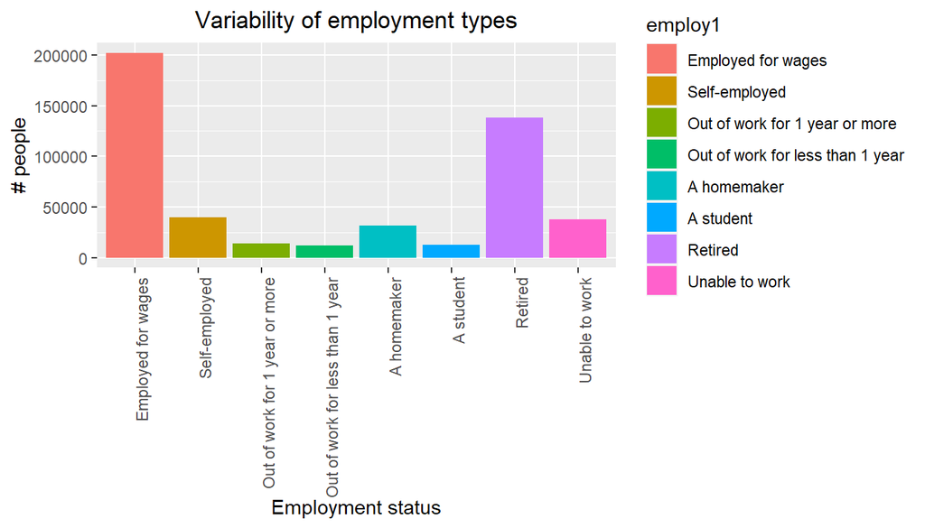

```r
# plots general employee variability
p1 <- ggplot(data = brf1, aes(x = employ1, fill = employ1)) +
  labs(title = "Variability of employment types") +
  labs(x = "Employment status") + labs(y = "# people") +
  geom_bar() + theme(plot.title = element_text(hjust = 0.5))
p1 + theme(axis.text.x=element_text(angle = 90, hjust = 1))
```

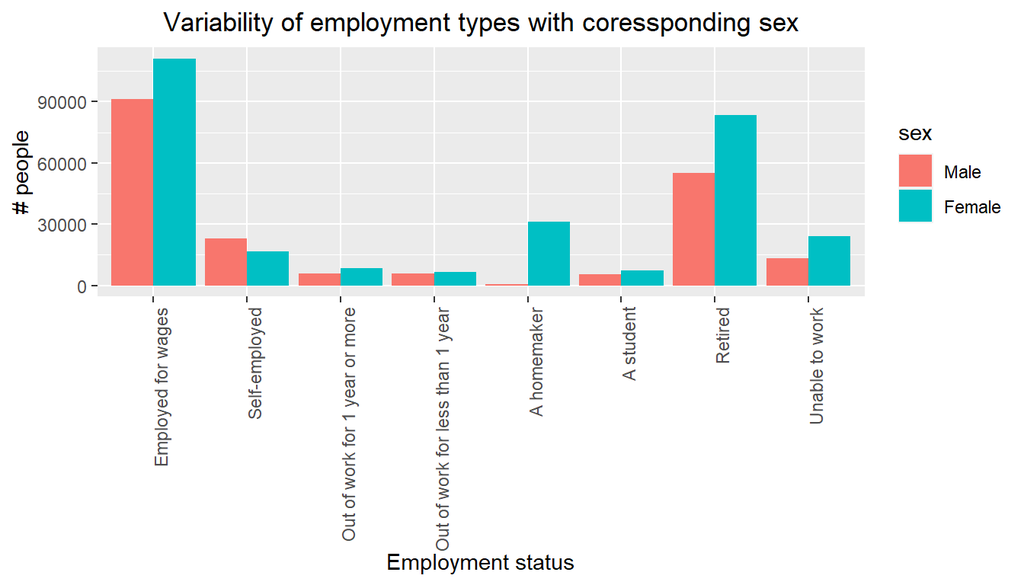

```r
#plots variability based on sex
p2 <-ggplot(data = brf1, aes(x = employ1, fill = sex)) +
  labs(title = "Variability of employment types with coressponding sex") +
  labs(x = "Employment status") + labs(y = "# people") +
  geom_bar(position = "dodge") + theme(plot.title = element_text(hjust = 0.5))
p2 + theme(axis.text.x=element_text(angle = 90, hjust = 1))
```